# Example Output

**NOTE: We will actually use two data sets in this example output. They come from the `lavaan` tutorial data sets; cfa data set is`HolzingerSwineford1939` and sem data set is `PoliticalDemocracy`**

**NOTE: You can download the RMarkdown file associated with this output by selecting the ‘Code’ button on the top-right of this document and selecting “Download Rmd”. You can also display the code used to produce each output by selecting the ‘Code’ buttons along the right of the document.**

**NOTE: for the entire document there are 2 tabs:**

- The “Results” tab contains ALL the results output
- The “Session Infor” tab contains information about the current R Session including what packages were loaded, how to cite the `lavaan` package and how to cite the R statistical software.

**NOTE: For each CFA or SEM model output there are 4 tabs:**

- The “Summary Output” tab display nice looking tables summarizing the model results
- The “Diagram Output” tab will display a model diagram
- The “Residual Correlation Matrix” tab will display the residual correlation matrix
- The “Full Output” tab will display the results from `summary()` along with parameter estimates and modification indices. This way you can still get the full output from a lavaan model as it provides more information than the “Summary Output”. You can also add additional output to this section if you need more info about the model.

**Once you install the package, you will be able to access this Rmarkdown template by going to**:

File -> New File -> R Markdown… -> From Template -> CFA/SEM (lavaan)

In the YAML header you will need to specify the default parameters (select the ‘Code’ button to the right):

```r
params:
  import.file: ""       # Relative file path to data
  mimic: "lavaan"       # Which software program to mimic?
  estimator: "ML"       # Which estimation method to use?
  missing: "ML"         # How to deal with missing values: "ML" or "listwise"
  std.lv: TRUE          # For CFAs, set latent variances to 1?
  std.ov: FALSE         # Staandardize all observed varialbes?
  test: "standard"      # How to compute Chi-square test statistic
  se: "standard"        # Calcualte standard errors: "standard" or "bootstrap"
  bootstrap: 1000       # If se = "bootstrap" how many boostrap samples?
```

Last updated: May 11 2020

## Results

### Setup

Required Packages

```r
library(readr)
library(lavaan)
library(psych)
library(semoutput)
library(semPlot)
library(sjPlot)
```

Import Data

Data file:

```r
## Import Data
data <- read_csv(params$import.file)
```

```r
cfa_data <- dplyr::select(HolzingerSwineford1939, -id, -school)
sem_data <- PoliticalDemocracy
```

lavaan parameters:

mimic = lavaan

estimator = ML

missing = ML

std.lv = TRUE

std.ov = FALSE

test = standard

se = standard

bootstrap = 1000

### Descriptives

Typically there is only one descriptive table displayed but since we have two data sets for this one output two descriptive tables are displayed.

```r
# Prints basic descriptive statistics
sem_descriptives(cfa_data)
```

Descriptive Statistics

| Variable | n | Mean | SD | min | max | Skewness | Kurtosis | % Missing |
| --- | --- | --- | --- | --- | --- | --- | --- | --- |
| agemo | 301 | 5.38 | 3.45 | 0.00 | 11.00 | 0.09 | -1.21 | 0.00 |
| ageyr | 301 | 13.00 | 1.05 | 11.00 | 16.00 | 0.70 | 0.25 | 0.00 |
| grade | 300 | 7.48 | 0.50 | 7.00 | 8.00 | 0.09 | -2.00 | 0.33 |
| sex | 301 | 1.51 | 0.50 | 1.00 | 2.00 | -0.06 | -2.01 | 0.00 |
| x1 | 301 | 4.94 | 1.17 | 0.67 | 8.50 | -0.26 | 0.36 | 0.00 |
| x2 | 301 | 6.09 | 1.18 | 2.25 | 9.25 | 0.47 | 0.38 | 0.00 |
| x3 | 301 | 2.25 | 1.13 | 0.25 | 4.50 | 0.39 | -0.89 | 0.00 |
| x4 | 301 | 3.06 | 1.16 | 0.00 | 6.33 | 0.27 | 0.12 | 0.00 |
| x5 | 301 | 4.34 | 1.29 | 1.00 | 7.00 | -0.35 | -0.53 | 0.00 |
| x6 | 301 | 2.19 | 1.10 | 0.14 | 6.14 | 0.87 | 0.88 | 0.00 |
| x7 | 301 | 4.19 | 1.09 | 1.30 | 7.43 | 0.25 | -0.27 | 0.00 |
| x8 | 301 | 5.53 | 1.01 | 3.05 | 10.00 | 0.53 | 1.24 | 0.00 |
| x9 | 301 | 5.37 | 1.01 | 2.78 | 9.25 | 0.21 | 0.34 | 0.00 |

Total N = 301

```r
sem_descriptives(sem_data)
```

Descriptive Statistics

| Variable | n | Mean | SD | min | max | Skewness | Kurtosis | % Missing |
| --- | --- | --- | --- | --- | --- | --- | --- | --- |
| x1 | 75 | 5.05 | 0.73 | 3.78 | 6.74 | 0.26 | -0.66 | 0 |
| x2 | 75 | 4.79 | 1.51 | 1.39 | 7.87 | -0.36 | -0.46 | 0 |
| x3 | 75 | 3.56 | 1.41 | 1.00 | 6.42 | 0.09 | -0.86 | 0 |
| y1 | 75 | 5.46 | 2.62 | 1.25 | 10.00 | -0.10 | -1.10 | 0 |
| y2 | 75 | 4.26 | 3.95 | 0.00 | 10.00 | 0.33 | -1.44 | 0 |
| y3 | 75 | 6.56 | 3.28 | 0.00 | 10.00 | -0.62 | -0.62 | 0 |
| y4 | 75 | 4.45 | 3.35 | 0.00 | 10.00 | 0.12 | -1.16 | 0 |
| y5 | 75 | 5.14 | 2.61 | 0.00 | 10.00 | -0.24 | -0.68 | 0 |
| y6 | 75 | 2.98 | 3.37 | 0.00 | 10.00 | 0.93 | -0.34 | 0 |
| y7 | 75 | 6.20 | 3.29 | 0.00 | 10.00 | -0.58 | -0.63 | 0 |
| y8 | 75 | 4.04 | 3.25 | 0.00 | 10.00 | 0.46 | -0.88 | 0 |

Total N = 75

### Correlation Matrix

There are also two correlation matrices

This is a publication quality correlation matrix that can be inserted into a manuscript.

```r
# Uses sjPlot to print a nice looking correlation table
sjt.corr(cfa_data, na.deletion = "pairwise", digits = 2, triangle = "lower")
```

|  | sex | ageyr | agemo | grade | x1 | x2 | x3 | x4 | x5 | x6 | x7 | x8 | x9 |
| --- | --- | --- | --- | --- | --- | --- | --- | --- | --- | --- | --- | --- | --- |
| sex |  |  |  |  |  |  |  |  |  |  |  |  |  |
| ageyr | -0.16** |  |  |  |  |  |  |  |  |  |  |  |  |
| agemo | 0.02 | -0.24*** |  |  |  |  |  |  |  |  |  |  |  |
| grade | -0.03 | 0.51*** | -0.00 |  |  |  |  |  |  |  |  |  |  |
| x1 | -0.08 | -0.06 | 0.05 | 0.17** |  |  |  |  |  |  |  |  |  |
| x2 | -0.12* | -0.02 | 0.05 | 0.14* | 0.30*** |  |  |  |  |  |  |  |  |
| x3 | -0.18** | 0.04 | 0.03 | 0.14* | 0.44*** | 0.34*** |  |  |  |  |  |  |  |
| x4 | 0.12* | -0.20*** | -0.02 | 0.21*** | 0.37*** | 0.15** | 0.16** |  |  |  |  |  |  |
| x5 | 0.06 | -0.22*** | -0.04 | 0.17** | 0.29*** | 0.14* | 0.08 | 0.73*** |  |  |  |  |  |
| x6 | 0.01 | -0.17** | 0.01 | 0.16** | 0.36*** | 0.19*** | 0.20*** | 0.70*** | 0.72*** |  |  |  |  |
| x7 | 0.12* | 0.11 | 0.06 | 0.35*** | 0.07 | -0.08 | 0.07 | 0.17** | 0.10 | 0.12* |  |  |  |
| x8 | -0.04 | 0.24*** | 0.01 | 0.30*** | 0.22*** | 0.09 | 0.19** | 0.11 | 0.14* | 0.15** | 0.49*** |  |  |
| x9 | 0.05 | 0.10 | 0.03 | 0.22*** | 0.39*** | 0.21*** | 0.33*** | 0.21*** | 0.23*** | 0.21*** | 0.34*** | 0.45*** |  |
| Computed correlation used pearson-method with pairwise-deletion. |  |  |  |  |  |  |  |  |  |  |  |  |  |

```r
sjt.corr(sem_data, na.deletion = "pairwise", digits = 2, triangle = "lower")
```

|  | y1 | y2 | y3 | y4 | y5 | y6 | y7 | y8 | x1 | x2 | x3 |
| --- | --- | --- | --- | --- | --- | --- | --- | --- | --- | --- | --- |
| y1 |  |  |  |  |  |  |  |  |  |  |  |
| y2 | 0.60*** |  |  |  |  |  |  |  |  |  |  |
| y3 | 0.68*** | 0.45*** |  |  |  |  |  |  |  |  |  |
| y4 | 0.69*** | 0.72*** | 0.61*** |  |  |  |  |  |  |  |  |
| y5 | 0.74*** | 0.54*** | 0.58*** | 0.65*** |  |  |  |  |  |  |  |
| y6 | 0.65*** | 0.71*** | 0.43*** | 0.66*** | 0.56*** |  |  |  |  |  |  |
| y7 | 0.67*** | 0.58*** | 0.65*** | 0.68*** | 0.68*** | 0.61*** |  |  |  |  |  |
| y8 | 0.67*** | 0.61*** | 0.53*** | 0.74*** | 0.63*** | 0.75*** | 0.71*** |  |  |  |  |
| x1 | 0.38*** | 0.21 | 0.33** | 0.47*** | 0.56*** | 0.34** | 0.39*** | 0.46*** |  |  |  |
| x2 | 0.32** | 0.25* | 0.31** | 0.44*** | 0.52*** | 0.35** | 0.40*** | 0.46*** | 0.89*** |  |  |
| x3 | 0.25* | 0.21 | 0.23 | 0.39*** | 0.43*** | 0.33** | 0.35** | 0.37** | 0.80*** | 0.85*** |  |
| Computed correlation used pearson-method with pairwise-deletion. |  |  |  |  |  |  |  |  |  |  |  |

### EFA

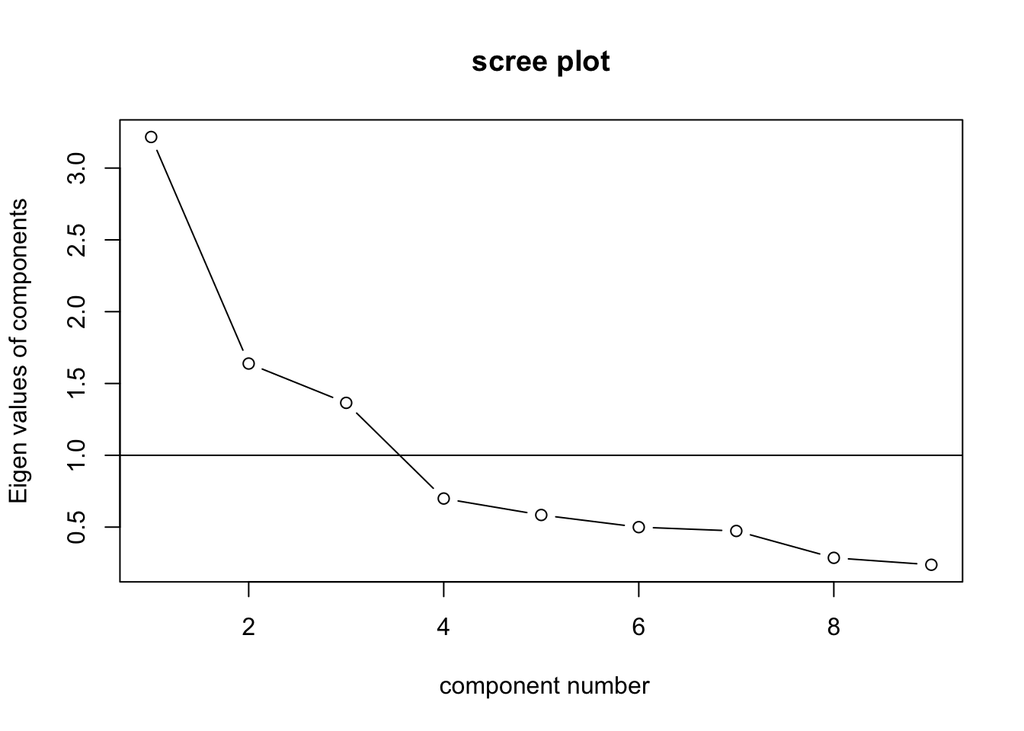

```r
efa_data <- dplyr::select(cfa_data, dplyr::starts_with("x"))

## Determine the number of factors to extract
VSS.scree(efa_data)
```

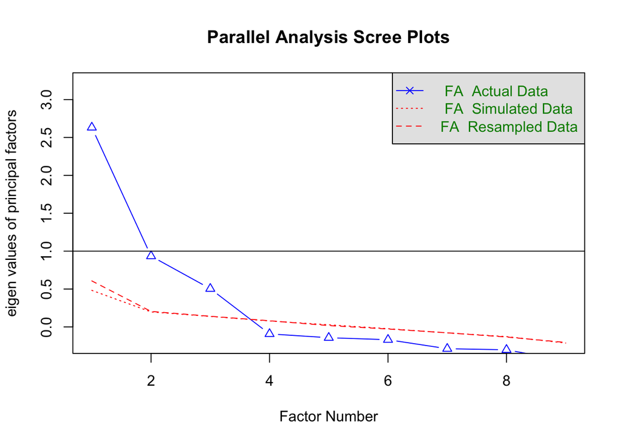

```
## Parallel analysis suggests that the number of factors =  3  and the number of components =  NA
```

```r
fa.parallel(efa_data, fa = "fa")
```

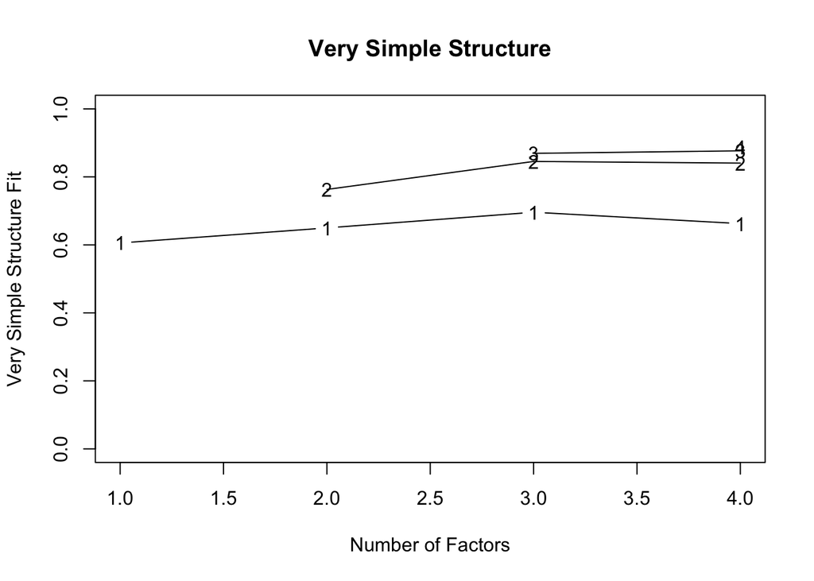

```
##
## Very Simple Structure
## Call: vss(x = x, n = n, rotate = rotate, diagonal = diagonal, fm = fm,
##     n.obs = n.obs, plot = plot, title = title, use = use, cor = cor)
## VSS complexity 1 achieves a maximimum of 0.7  with  3  factors
## VSS complexity 2 achieves a maximimum of 0.85  with  3  factors
##
## The Velicer MAP achieves a minimum of 0.06  with  2  factors
## BIC achieves a minimum of  -45.93  with  3  factors
## Sample Size adjusted BIC achieves a minimum of  -9.72  with  4  factors
##
## Statistics by number of factors
##   vss1 vss2   map dof chisq    prob sqresid  fit RMSEA BIC SABIC complex eChisq
## 1 0.61 0.00 0.080  27 358.3 1.4e-59     6.4 0.61 0.202 204 289.8     1.0  468.7
## 2 0.65 0.76 0.063  19 129.2 2.0e-18     3.9 0.76 0.139  21  81.0     1.2  154.1
## 3 0.70 0.85 0.068  12  22.6 3.2e-02     2.1 0.87 0.054 -46  -7.9     1.3    7.9
## 4 0.66 0.84 0.120   6   5.5 4.8e-01     1.8 0.89 0.000 -29  -9.7     1.4    1.7
##     SRMR eCRMS eBIC
## 1 0.1471 0.170  315
## 2 0.0843 0.116   46
## 3 0.0191 0.033  -61
## 4 0.0088 0.021  -33
```

```r
VSS(efa_data, n = 4, rotate = "varimax")
```

```r
## Conduct EFA analysis with nfactors determined from methods above
efa_fit <- fa(efa_data, fm = "pa", nfactors = 3, rotate = "varimax")
```

#### Summary Output

```r
efa_method(efa_fit)
```

Extraction Method

| Sample.Size | Method | Factors.Extracted | Rotation |
| --- | --- | --- | --- |
| 301 | Principal Axis Factoring | 3 | Varimax |

```r
efa_var(efa_fit)
```

Total Variance Explained

| Factor | Eigenvalue | Proportion Var | Cumulative Var |
| --- | --- | --- | --- |
| 1 | 2.187 | 0.243 | 0.243 |
| 3 | 1.341 | 0.149 | 0.392 |
| 2 | 1.328 | 0.148 | 0.540 |

```r
efa_loadings(efa_fit)
```

Factor Loadings

| Variable | Factors F1 | Factors F3 | Factors F2 | h2 |
| --- | --- | --- | --- | --- |
| x1 | 0.279 | 0.613 | 0.152 | 0.477 |
| x2 | 0.102 | 0.494 | -0.030 | 0.256 |
| x3 | 0.038 | 0.659 | 0.129 | 0.453 |
| x4 | 0.832 | 0.161 | 0.099 | 0.728 |
| x5 | 0.859 | 0.088 | 0.089 | 0.753 |
| x6 | 0.799 | 0.214 | 0.086 | 0.692 |
| x7 | 0.093 | -0.081 | 0.705 | 0.512 |
| x8 | 0.051 | 0.170 | 0.702 | 0.524 |
| x9 | 0.130 | 0.414 | 0.522 | 0.461 |

```r
efa_rotmatrix(efa_fit)
```

Factor Rotation Matrix

| Factor | 1 | 2 | 3 |
| --- | --- | --- | --- |
| 1 | 0.784 | 0.387 | 0.486 |
| 2 | -0.583 | 0.727 | 0.361 |
| 3 | -0.213 | -0.566 | 0.796 |

#### Diagram Output

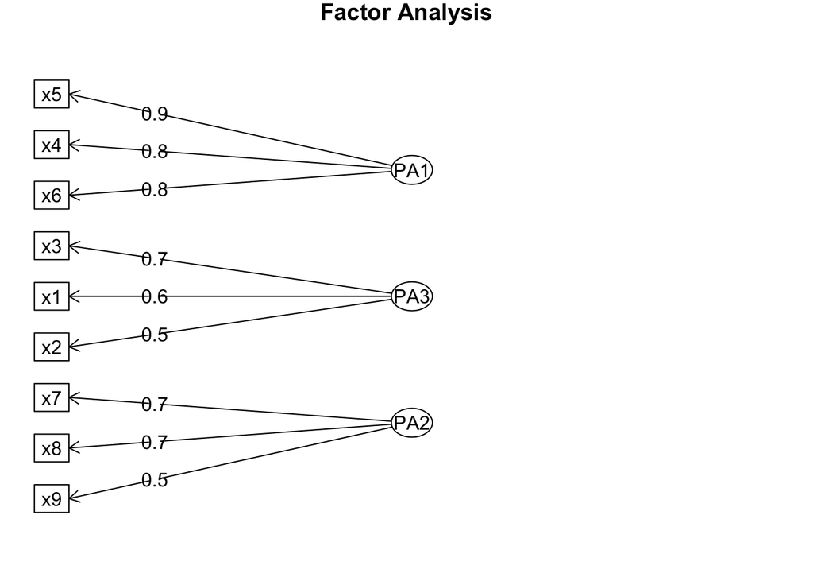

```r
fa.diagram(efa_fit)
```

#### Full Output

```r
efa_fit
```

```
## Factor Analysis using method =  pa
## Call: fa(r = efa_data, nfactors = 3, rotate = "varimax", fm = "pa")
## Standardized loadings (pattern matrix) based upon correlation matrix
##     PA1   PA3   PA2   h2   u2 com
## x1 0.28  0.61  0.15 0.48 0.52 1.5
## x2 0.10  0.49 -0.03 0.26 0.74 1.1
## x3 0.04  0.66  0.13 0.45 0.55 1.1
## x4 0.83  0.16  0.10 0.73 0.27 1.1
## x5 0.86  0.09  0.09 0.75 0.25 1.0
## x6 0.80  0.21  0.09 0.69 0.31 1.2
## x7 0.09 -0.08  0.70 0.51 0.49 1.1
## x8 0.05  0.17  0.70 0.52 0.48 1.1
## x9 0.13  0.41  0.52 0.46 0.54 2.0
##
##                        PA1  PA3  PA2
## SS loadings           2.19 1.34 1.33
## Proportion Var        0.24 0.15 0.15
## Cumulative Var        0.24 0.39 0.54
## Proportion Explained  0.45 0.28 0.27
## Cumulative Proportion 0.45 0.73 1.00
##
## Mean item complexity =  1.3
## Test of the hypothesis that 3 factors are sufficient.
##
## The degrees of freedom for the null model are  36  and the objective function was  3.05 with Chi Square of  904.1
## The degrees of freedom for the model are 12  and the objective function was  0.08
##
## The root mean square of the residuals (RMSR) is  0.02
## The df corrected root mean square of the residuals is  0.03
##
## The harmonic number of observations is  301 with the empirical chi square  7.87  with prob <  0.8
## The total number of observations was  301  with Likelihood Chi Square =  22.54  with prob <  0.032
##
## Tucker Lewis Index of factoring reliability =  0.963
## RMSEA index =  0.054  and the 90 % confidence intervals are  0.016 0.088
## BIC =  -45.95
## Fit based upon off diagonal values = 1
## Measures of factor score adequacy
##                                                    PA1  PA3  PA2
## Correlation of (regression) scores with factors   0.93 0.81 0.84
## Multiple R square of scores with factors          0.87 0.66 0.70
## Minimum correlation of possible factor scores     0.74 0.32 0.41
```

### CFA

```r
# factors is a list of the latent factor names. To be used for printing lavaan output to nice looking tables. Not needed to run actual lavaan model
factors <- c("visual", "textual", "speed")
# Specify the model parameters. Must be incased within single or double quotes. Can add labels to organize parameter specifications. I provided just some example labels, they are not required though and you can use whatever labels you want. You need to know how lavaan works! See http://lavaan.ugent.be/tutorial/index.html for more information on how to specify the model parameters
model <- '
# latent factors
visual =~ x1 + x2 + x3
textual =~ x4 + x5 + x6
speed =~ x7 + x8 + x9

# correlated errors

# constraints

'
# You might want to specify other arguments. But this is pretty standard.
#std.lv = TRUE means that the latent factor variances are set to 1. If False, then the path for the first variable on the factor specificed in the model will be set to 1.
fit <- cfa(model = model, data = cfa_data, mimic = params$mimic,
           estimator = params$estimator, missing = params$missing,
           std.lv = params$std.lv, std.ov = params$std.ov,
           test = params$test, se = params$se, bootstrap = params$bootstrap)
```

#### Summary Output

```r
## This tab will print out summary result tables with the most important information. Fit stats, standardized path values, etc...
sem_sig(fit)
```

Model Significance

| Sample.Size | Chi.Square | df | p.value |
| --- | --- | --- | --- |
| 301 | 85.306 | 24 | 0 |

```r
sem_fitmeasures(fit)
```

Model Fit Measures

| CFI | RMSEA | RMSEA.Lower | RMSEA.Upper | AIC | BIC |
| --- | --- | --- | --- | --- | --- |
| 0.931 | 0.092 | 0.071 | 0.114 | 7535.49 | 7646.703 |

```r
sem_factorloadings(fit, standardized = TRUE, ci = "standardized")
```

Factor Loadings

| Latent Factor | Indicator | Standardized Loadings | Standardized sig | Standardized p | Standardized Lower.CI | Standardized Upper.CI | Standardized SE | Standardized z |
| --- | --- | --- | --- | --- | --- | --- | --- | --- |
| visual | x1 | 0.772 | *** | 0 | 0.659 | 0.885 | 0.058 | 13.416 |
| visual | x2 | 0.424 | *** | 0 | 0.301 | 0.547 | 0.063 | 6.752 |
| visual | x3 | 0.581 | *** | 0 | 0.467 | 0.696 | 0.058 | 9.942 |
| textual | x4 | 0.852 | *** | 0 | 0.807 | 0.896 | 0.023 | 37.612 |
| textual | x5 | 0.855 | *** | 0 | 0.812 | 0.899 | 0.022 | 38.530 |
| textual | x6 | 0.838 | *** | 0 | 0.792 | 0.884 | 0.024 | 35.598 |
| speed | x7 | 0.570 | *** | 0 | 0.455 | 0.684 | 0.058 | 9.767 |
| speed | x8 | 0.723 | *** | 0 | 0.601 | 0.845 | 0.062 | 11.608 |
| speed | x9 | 0.665 | *** | 0 | 0.535 | 0.795 | 0.066 | 10.063 |

```r
sem_factorcor(fit, factors = factors)
```

Latent Factor Correlations

| Factor 1 | Factor 2 | r | sig | p | Lower.CI | Upper.CI | SE |
| --- | --- | --- | --- | --- | --- | --- | --- |
| visual | textual | 0.459 | *** | 0 | 0.334 | 0.583 | 0.063 |
| visual | speed | 0.471 | *** | 0 | 0.302 | 0.640 | 0.086 |
| textual | speed | 0.283 | *** | 0 | 0.143 | 0.423 | 0.071 |

```r
sem_factorvar(fit, factors = factors)
```

Latent Factor Variance/Residual Variance

| Factor 1 | Factor 2 | var | var.std | sig | p |
| --- | --- | --- | --- | --- | --- |

```r
sem_rsquared(fit)
```

R-Squared Values

| Variable | R-Squared |
| --- | --- |
| x1 | 0.5957993 |
| x2 | 0.1794379 |
| x3 | 0.3377150 |
| x4 | 0.7251925 |
| x5 | 0.7311370 |
| x6 | 0.7022611 |
| x7 | 0.3243475 |
| x8 | 0.5227931 |
| x9 | 0.4422378 |

#### Diagram Output

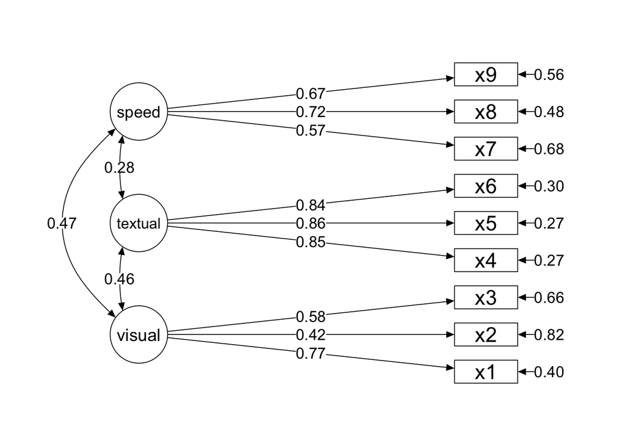

```r
## This tab will print out a model diagram. Pretty freak'n cool!
semPaths(fit, latents = factors, whatLabels = "std", layout = "tree2",
         rotation = 2, style = "lisrel", optimizeLatRes = TRUE,
         intercepts = FALSE, residuals = TRUE, curve = 1, curvature = 3,
         sizeLat = 10, nCharNodes = 8, sizeMan = 11, sizeMan2 = 4,
         edge.label.cex = 1.2, edge.color = "#000000")
```

```r
## If you want to modify the plot see ?semPlot::semPaths for argument descriptions
```

#### Residual Correlation Matrix

```r
## If you want to see the residual correlation matrix
sem_residuals(fit)
```

|  | x1 | x2 | x3 | x4 | x5 | x6 | x7 | x8 | x9 |
| --- | --- | --- | --- | --- | --- | --- | --- | --- | --- |
| x1 |  |  |  |  |  |  |  |  |  |
| x2 | -0.03 |  |  |  |  |  |  |  |  |
| x3 | -0.01 | 0.09 |  |  |  |  |  |  |  |
| x4 | 0.07 | -0.01 | -0.07 |  |  |  |  |  |  |
| x5 | -0.01 | -0.03 | -0.15 | 0.01 |  |  |  |  |  |
| x6 | 0.06 | 0.03 | -0.03 | -0.01 | 0.00 |  |  |  |  |
| x7 | -0.14 | -0.19 | -0.08 | 0.04 | -0.04 | -0.01 |  |  |  |
| x8 | -0.04 | -0.05 | -0.01 | -0.07 | -0.04 | -0.02 | 0.07 |  |  |
| x9 | 0.15 | 0.07 | 0.15 | 0.05 | 0.07 | 0.06 | -0.04 | -0.03 |  |

#### Full Output

##### Summary

```r
summary(fit, fit.measures = TRUE, standardized = TRUE)
```

```
## lavaan 0.6-5 ended normally after 42 iterations
##
##   Estimator                                         ML
##   Optimization method                           NLMINB
##   Number of free parameters                         30
##
##   Number of observations                           301
##   Number of missing patterns                         1
##
## Model Test User Model:
##
##   Test statistic                                85.306
##   Degrees of freedom                                24
##   P-value (Chi-square)                           0.000
##
## Model Test Baseline Model:
##
##   Test statistic                               918.852
##   Degrees of freedom                                36
##   P-value                                        0.000
##
## User Model versus Baseline Model:
##
##   Comparative Fit Index (CFI)                    0.931
##   Tucker-Lewis Index (TLI)                       0.896
##
## Loglikelihood and Information Criteria:
##
##   Loglikelihood user model (H0)              -3737.745
##   Loglikelihood unrestricted model (H1)      -3695.092
##
##   Akaike (AIC)                                7535.490
##   Bayesian (BIC)                              7646.703
##   Sample-size adjusted Bayesian (BIC)         7551.560
##
## Root Mean Square Error of Approximation:
##
##   RMSEA                                          0.092
##   90 Percent confidence interval - lower         0.071
##   90 Percent confidence interval - upper         0.114
```

[output cut: 49 more lines]

```
##
## Variances:
##                    Estimate  Std.Err  z-value  P(>|z|)   Std.lv  Std.all
##    .x1                0.549    0.119    4.612    0.000    0.549    0.404
##    .x2                1.134    0.104   10.875    0.000    1.134    0.821
##    .x3                0.844    0.095    8.881    0.000    0.844    0.662
##    .x4                0.371    0.048    7.739    0.000    0.371    0.275
##    .x5                0.446    0.058    7.703    0.000    0.446    0.269
##    .x6                0.356    0.043    8.200    0.000    0.356    0.298
##    .x7                0.799    0.088    9.130    0.000    0.799    0.676
##    .x8                0.488    0.092    5.321    0.000    0.488    0.477
##    .x9                0.566    0.091    6.250    0.000    0.566    0.558
##     visual            1.000                               1.000    1.000
##     textual           1.000                               1.000    1.000
##     speed             1.000                               1.000    1.000
```

##### Parameter Estimates

```r
standardizedSolution(fit)
```

```
##        lhs op     rhs est.std    se      z pvalue ci.lower ci.upper
## 1   visual =~      x1   0.772 0.058 13.416      0    0.659    0.885
## 2   visual =~      x2   0.424 0.063  6.752      0    0.301    0.547
## 3   visual =~      x3   0.581 0.058  9.942      0    0.467    0.696
## 4  textual =~      x4   0.852 0.023 37.612      0    0.807    0.896
## 5  textual =~      x5   0.855 0.022 38.530      0    0.812    0.899
## 6  textual =~      x6   0.838 0.024 35.598      0    0.792    0.884
## 7    speed =~      x7   0.570 0.058  9.767      0    0.455    0.684
## 8    speed =~      x8   0.723 0.062 11.608      0    0.601    0.845
## 9    speed =~      x9   0.665 0.066 10.063      0    0.535    0.795
## 10      x1 ~~      x1   0.404 0.089  4.551      0    0.230    0.578
## 11      x2 ~~      x2   0.821 0.053 15.438      0    0.716    0.925
## 12      x3 ~~      x3   0.662 0.068  9.748      0    0.529    0.795
## 13      x4 ~~      x4   0.275 0.039  7.126      0    0.199    0.350
## 14      x5 ~~      x5   0.269 0.038  7.084      0    0.194    0.343
```

[output cut: 22 more lines]

##### Modification Indices

```r
modificationIndices(fit, sort. = TRUE, minimum.value = 3)
```

```
##        lhs op rhs     mi    epc sepc.lv sepc.all sepc.nox
## 42  visual =~  x9 36.411  0.519   0.519    0.515    0.515
## 88      x7 ~~  x8 34.145  0.536   0.536    0.859    0.859
## 40  visual =~  x7 18.631 -0.380  -0.380   -0.349   -0.349
## 90      x8 ~~  x9 14.946 -0.423  -0.423   -0.805   -0.805
## 45 textual =~  x3  9.151 -0.269  -0.269   -0.238   -0.238
## 67      x2 ~~  x7  8.918 -0.183  -0.183   -0.192   -0.192
## 43 textual =~  x1  8.903  0.347   0.347    0.297    0.297
## 63      x2 ~~  x3  8.532  0.218   0.218    0.223    0.223
## 71      x3 ~~  x5  7.858 -0.130  -0.130   -0.212   -0.212
## 38  visual =~  x5  7.441 -0.189  -0.189   -0.147   -0.147
## 62      x1 ~~  x9  7.335  0.138   0.138    0.247    0.247
## 77      x4 ~~  x6  6.221 -0.235  -0.235   -0.646   -0.646
## 78      x4 ~~  x7  5.920  0.098   0.098    0.180    0.180
## 60      x1 ~~  x7  5.420 -0.129  -0.129   -0.195   -0.195
## 89      x7 ~~  x9  5.183 -0.187  -0.187   -0.278   -0.278
## 48 textual =~  x9  4.796  0.137   0.137    0.136    0.136
## 41  visual =~  x8  4.295 -0.189  -0.189   -0.187   -0.187
## 75      x3 ~~  x9  4.126  0.102   0.102    0.147    0.147
## 79      x4 ~~  x8  3.805 -0.069  -0.069   -0.162   -0.162
## 55      x1 ~~  x2  3.606 -0.184  -0.184   -0.233   -0.233
## 57      x1 ~~  x4  3.554  0.078   0.078    0.173    0.173
## 47 textual =~  x8  3.359 -0.120  -0.120   -0.118   -0.118
```

### SEM

```r
# factors is a list of the latent factor names. To be used for printing lavaan output to nice looking tables. Not needed to run actual lavaan model
factors <- c("dem60", "ind60", "dem65")
# Specify the model parameters. Must be incased within single or double quotes. Can add labels to organize parameter specifications. I provided just some example labels, they are not required though and you can use whatever labels you want. You need to know how lavaan works! See http://lavaan.ugent.be/tutorial/index.html for more information on how to specify the model parameters
model <- '
# measurement model
ind60 =~ x1 + x2 + x3
dem60 =~ y1 + y2 + y3 + y4
dem65 =~ y5 + y6 + y7 + y8

# regressions
dem60 ~ ind60
dem65 ~ ind60 + dem60

# covariances
y1 ~~ y5
y2 ~~ y4 + y6
y3 ~~ y7
y4 ~~ y8
y6 ~~ y8

# variances

'
# You might want to specify other arguments. But this is pretty standard.
#std.lv = TRUE means that the latent factor variances are set to 1. If False, then the path for the first variable on the factor specificed in the model will be set to 1. For an SEM, it is better to set as FALSE. And if you want a latent factor variance set to 1 then specify it in the model and include NA* before the first variable on the factor. See http://lavaan.ugent.be/tutorial/index.html for more details
fit <- sem(model = model, data = sem_data, mimic = params$mimic,
           estimator = params$estimator, missing = params$missing,
           std.lv = FALSE, std.ov = params$std.ov,
           test = params$test, se = params$se, bootstrap = params$bootstrap)
```

#### Summary Output

```r
## This tab will print out summary result tables with the most important information. Fit stats, standardized path values, etc...
sem_sig(fit)
```

Model Significance

| Sample.Size | Chi.Square | df | p.value |
| --- | --- | --- | --- |
| 75 | 38.125 | 35 | 0.329 |

```r
sem_fitmeasures(fit)
```

Model Fit Measures

| CFI | RMSEA | RMSEA.Lower | RMSEA.Upper | AIC | BIC |
| --- | --- | --- | --- | --- | --- |
| 0.995 | 0.035 | 0 | 0.092 | 3179.582 | 3276.916 |

```r
sem_factorloadings(fit, standardized = TRUE, ci = "standardized")
```

Factor Loadings

| Latent Factor | Indicator | Standardized Loadings | Standardized sig | Standardized p | Standardized Lower.CI | Standardized Upper.CI | Standardized SE | Standardized z |
| --- | --- | --- | --- | --- | --- | --- | --- | --- |
| ind60 | x1 | 0.920 | *** | 0 | 0.874 | 0.965 | 0.023 | 39.658 |
| ind60 | x2 | 0.973 | *** | 0 | 0.941 | 1.005 | 0.017 | 58.917 |
| ind60 | x3 | 0.872 | *** | 0 | 0.812 | 0.933 | 0.031 | 28.304 |
| dem60 | y1 | 0.850 | *** | 0 | 0.765 | 0.936 | 0.044 | 19.435 |
| dem60 | y2 | 0.717 | *** | 0 | 0.592 | 0.843 | 0.064 | 11.207 |
| dem60 | y3 | 0.722 | *** | 0 | 0.596 | 0.849 | 0.064 | 11.221 |
| dem60 | y4 | 0.846 | *** | 0 | 0.759 | 0.933 | 0.044 | 19.020 |
| dem65 | y5 | 0.808 | *** | 0 | 0.713 | 0.903 | 0.048 | 16.698 |
| dem65 | y6 | 0.746 | *** | 0 | 0.634 | 0.858 | 0.057 | 13.031 |
| dem65 | y7 | 0.824 | *** | 0 | 0.734 | 0.913 | 0.046 | 18.063 |
| dem65 | y8 | 0.828 | *** | 0 | 0.738 | 0.918 | 0.046 | 18.030 |

```r
sem_paths(fit, standardized = TRUE, ci = "standardized")
```

Regression Paths

Standardized

Predictor

DV

Path Values

SE

z

sig

p

Lower.CI

Upper.CI

ind60

dem60

0.447

0.105

4.267

***

0.000

0.242

0.652

ind60

dem65

0.182

0.073

2.498

0.013

0.039

0.325

dem60

dem65

0.885

0.052

17.100

***

0.000

0.784

0.987

```r
sem_factorcor(fit, factors = factors)
```

Latent Factor Correlations

| Factor 1 | Factor 2 | r | sig | p | Lower.CI | Upper.CI | SE |
| --- | --- | --- | --- | --- | --- | --- | --- |

```r
sem_factorvar(fit, factors = factors)
```

Latent Factor Variance/Residual Variance

| Factor 1 | Factor 2 | var | var.std | sig | p |
| --- | --- | --- | --- | --- | --- |
| ind60 | ind60 | 0.448 | 1.000 | *** | 0.000 |
| dem60 | dem60 | 3.956 | 0.800 | *** | 0.000 |
| dem65 | dem65 | 0.172 | 0.039 |  | 0.434 |

```r
sem_rsquared(fit)
```

R-Squared Values

| Variable | R-Squared |
| --- | --- |
| x1 | 0.8461294 |
| x2 | 0.9467924 |
| x3 | 0.7606255 |
| y1 | 0.7232243 |
| y2 | 0.5142639 |
| y3 | 0.5217879 |
| y4 | 0.7152243 |
| y5 | 0.6528920 |
| y6 | 0.5565263 |
| y7 | 0.6784382 |
| y8 | 0.6853214 |
| dem60 | 0.1995522 |
| dem65 | 0.9609949 |

#### Diagram Output

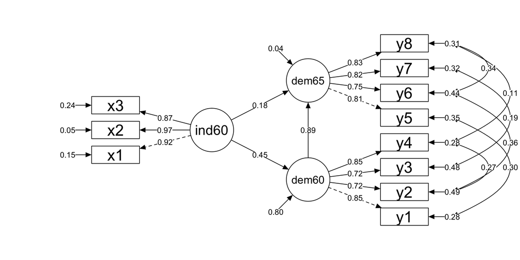

```r
## This tab will print out a model diagram. Pretty freak'n cool!
semPaths(fit, latents = factors, whatLabels = "std", layout = "tree2",
         rotation = 2, style = "lisrel", optimizeLatRes = TRUE,
         intercepts = FALSE, residuals = TRUE, curve = 1, curvature = 3,
         sizeLat = 10, nCharNodes = 8, sizeMan = 11, sizeMan2 = 4,
         edge.label.cex = .8, edge.color = "#000000")
```

```r
## If you want to modify the plot see ?semPlot::semPaths for argument descriptions
```

#### Residual Correlation Matrix

```r
## If you want to see the residual correlation matrix
sem_residuals(fit)
```

|  | x1 | x2 | x3 | y1 | y2 | y3 | y4 | y5 | y6 | y7 | y8 |
| --- | --- | --- | --- | --- | --- | --- | --- | --- | --- | --- | --- |
| x1 |  |  |  |  |  |  |  |  |  |  |  |
| x2 | 0.00 |  |  |  |  |  |  |  |  |  |  |
| x3 | 0.00 | 0.00 |  |  |  |  |  |  |  |  |  |
| y1 | 0.03 | -0.05 | -0.08 |  |  |  |  |  |  |  |  |
| y2 | -0.08 | -0.06 | -0.07 | -0.01 |  |  |  |  |  |  |  |
| y3 | 0.03 | 0.00 | -0.06 | 0.06 | -0.07 |  |  |  |  |  |  |
| y4 | 0.12 | 0.08 | 0.06 | -0.03 | 0.01 | 0.00 |  |  |  |  |  |
| y5 | 0.14 | 0.07 | 0.02 | -0.02 | -0.02 | 0.01 | -0.01 |  |  |  |  |
| y6 | -0.05 | -0.06 | -0.04 | 0.04 | 0.02 | -0.09 | 0.05 | -0.04 |  |  |  |
| y7 | -0.05 | -0.06 | -0.06 | 0.00 | 0.01 | 0.00 | 0.01 | 0.01 | -0.01 |  |  |
| y8 | 0.02 | -0.01 | -0.05 | -0.01 | 0.03 | -0.05 | 0.03 | -0.04 | 0.01 | 0.03 |  |

#### Full Output

##### Summary

```r
summary(fit, fit.measures = TRUE, standardized = TRUE)
```

```
## lavaan 0.6-5 ended normally after 83 iterations
##
##   Estimator                                         ML
##   Optimization method                           NLMINB
##   Number of free parameters                         42
##
##   Number of observations                            75
##   Number of missing patterns                         1
##
## Model Test User Model:
##
##   Test statistic                                38.125
##   Degrees of freedom                                35
##   P-value (Chi-square)                           0.329
##
## Model Test Baseline Model:
##
##   Test statistic                               730.654
##   Degrees of freedom                                55
##   P-value                                        0.000
##
## User Model versus Baseline Model:
##
##   Comparative Fit Index (CFI)                    0.995
##   Tucker-Lewis Index (TLI)                       0.993
##
## Loglikelihood and Information Criteria:
##
##   Loglikelihood user model (H0)              -1547.791
##   Loglikelihood unrestricted model (H1)      -1528.728
##
##   Akaike (AIC)                                3179.582
##   Bayesian (BIC)                              3276.916
##   Sample-size adjusted Bayesian (BIC)         3144.543
##
## Root Mean Square Error of Approximation:
##
##   RMSEA                                          0.035
##   90 Percent confidence interval - lower         0.000
##   90 Percent confidence interval - upper         0.092
```

[output cut: 69 more lines]

```
##                    Estimate  Std.Err  z-value  P(>|z|)   Std.lv  Std.all
##    .x1                0.082    0.020    4.136    0.000    0.082    0.154
##    .x2                0.120    0.070    1.712    0.087    0.120    0.053
##    .x3                0.467    0.089    5.233    0.000    0.467    0.239
##    .y1                1.891    0.469    4.035    0.000    1.891    0.277
##    .y2                7.373    1.346    5.479    0.000    7.373    0.486
##    .y3                5.067    0.968    5.233    0.000    5.067    0.478
##    .y4                3.148    0.756    4.165    0.000    3.148    0.285
##    .y5                2.351    0.489    4.810    0.000    2.351    0.347
##    .y6                4.954    0.895    5.532    0.000    4.954    0.443
##    .y7                3.431    0.728    4.715    0.000    3.431    0.322
##    .y8                3.254    0.707    4.603    0.000    3.254    0.315
##     ind60             0.448    0.087    5.170    0.000    1.000    1.000
##    .dem60             3.956    0.945    4.188    0.000    0.800    0.800
##    .dem65             0.172    0.220    0.783    0.434    0.039    0.039
```

##### Parameter Estimates

```r
standardizedSolution(fit)
```

```
##      lhs op   rhs est.std    se      z pvalue ci.lower ci.upper
## 1  ind60 =~    x1   0.920 0.023 39.658  0.000    0.874    0.965
## 2  ind60 =~    x2   0.973 0.017 58.917  0.000    0.941    1.005
## 3  ind60 =~    x3   0.872 0.031 28.304  0.000    0.812    0.933
## 4  dem60 =~    y1   0.850 0.044 19.435  0.000    0.765    0.936
## 5  dem60 =~    y2   0.717 0.064 11.207  0.000    0.592    0.843
## 6  dem60 =~    y3   0.722 0.064 11.221  0.000    0.596    0.849
## 7  dem60 =~    y4   0.846 0.044 19.020  0.000    0.759    0.933
## 8  dem65 =~    y5   0.808 0.048 16.698  0.000    0.713    0.903
## 9  dem65 =~    y6   0.746 0.057 13.031  0.000    0.634    0.858
## 10 dem65 =~    y7   0.824 0.046 18.063  0.000    0.734    0.913
## 11 dem65 =~    y8   0.828 0.046 18.030  0.000    0.738    0.918
## 12 dem60  ~ ind60   0.447 0.105  4.267  0.000    0.242    0.652
## 13 dem65  ~ ind60   0.182 0.073  2.498  0.013    0.039    0.325
## 14 dem65  ~ dem60   0.885 0.052 17.100  0.000    0.784    0.987
```

[output cut: 34 more lines]

##### Modification Indices

```r
modificationIndices(fit, sort. = TRUE, minimum.value = 3)
```

```
##      lhs op rhs    mi    epc sepc.lv sepc.all sepc.nox
## 52 ind60 =~  y4 4.796  0.862   0.577    0.174    0.174
## 53 ind60 =~  y5 4.456  0.835   0.559    0.215    0.215
## 70 dem65 =~  y4 4.261  1.420   2.986    0.898    0.898
## 99    y1 ~~  y3 3.771  0.849   0.849    0.274    0.274
## 74    x1 ~~  y2 3.040 -0.155  -0.155   -0.200   -0.200
```

## Session Info

```r
citation("lavaan")
```

```
  Yves Rosseel (2012). lavaan: An R Package for Structural Equation
  Modeling. Journal of Statistical Software, 48(2), 1-36. URL
  http://www.jstatsoft.org/v48/i02/.

A BibTeX entry for LaTeX users is

  @Article{,
    title = {{lavaan}: An {R} Package for Structural Equation Modeling},
    author = {Yves Rosseel},
    journal = {Journal of Statistical Software},
    year = {2012},
    volume = {48},
    number = {2},
    pages = {1--36},
    url = {http://www.jstatsoft.org/v48/i02/},
  }
```

```r
citation()
```

```
  R Core Team (2020). R: A language and environment for statistical
  computing. R Foundation for Statistical Computing, Vienna, Austria.
  URL https://www.R-project.org/.

A BibTeX entry for LaTeX users is

  @Manual{,
    title = {R: A Language and Environment for Statistical Computing},
    author = {{R Core Team}},
    organization = {R Foundation for Statistical Computing},
    address = {Vienna, Austria},
    year = {2020},
    url = {https://www.R-project.org/},
  }

We have invested a lot of time and effort in creating R, please cite it
when using it for data analysis. See also 'citation("pkgname")' for
citing R packages.
```

[session information not shown]